# Multi-variable linear regression

The multivariable linear regression analysis is used to create a model of a single variable, typically an energy consumption. We call this the *dependent* variable y. The model is constructed as a linear combination of *explanatory* or *independent* variables (x), like weather measurements or occupation. More information can be found on [wikipedia](https://en.wikipedia.org/wiki/Linear_regression).

The model is static. This means that the data set should not contain dynamic effects. For buildings, dynamic effects are mostly neglegible on a weekly basis unless the building has a very high thermal inertia.

Typical use of this analysis is to create a model of eg. the gas consumption of a building, and then use this model to detect and quantify changes in the gas consumption. For example, the savings resulting from a new gas boiler can be computed as the difference between the consumption predicted by the model and the actual consumption.

### Imports and loading data

```python
import opengrid as og
import pandas as pd
```

```python
df = og.datasets.get('gas_2016_hour')
# for this demo, we only compute a model for the sensor 313b
df = df[['313b']]
# load weather
dfw = og.datasets.get('weather_2016_hour')
```

### Compute degree-days

First we compute heating degree-days for different base temperatures. More information on the computation of degree-days can be found in [this demo](https://opengridcc.github.io/analysis/degree-days).

```python
%matplotlib inline
```

```python
# resample weather data to daily values and compute degree-days
dfw = dfw.resample('D').mean()
dfw_HDD = og.library.weather.compute_degree_days(ts=dfw['temperature'],
                                                  heating_base_temperatures=range(8, 18, 2),
                                                  cooling_base_temperatures=range(16, 26, 2)).bfill()
```

```python
# resample the gas consumption to daily values and add the weather data and the degree-days
df_day = df.resample('D').sum()/1000. # kWh/day
df_day = pd.concat([df_day, dfw, dfw_HDD], axis=1).loc['2016']
```

# Create a monthly model for the gas consumption

```python
# resample to monthly data
df_month = df_day.resample('MS').sum()
# we use the first half of 2016 as training data and will use the model to predict the second half of 2016
df_training = df_month.loc[:'2016-06-01']
```

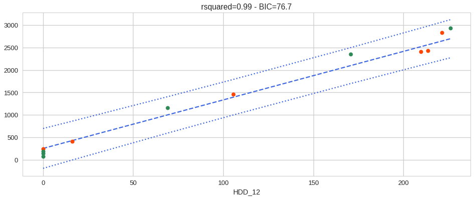

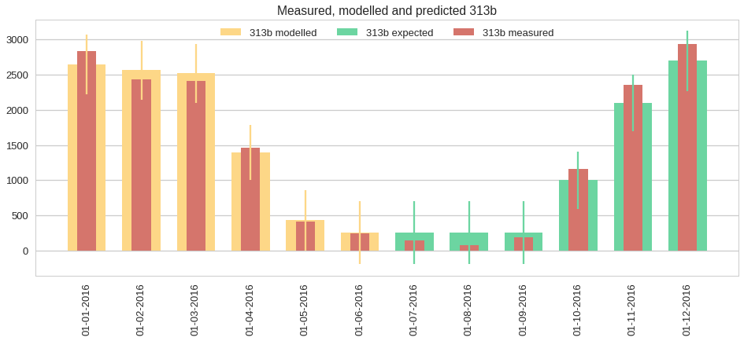

```python
# create the model
mvlr = og.MultiVarLinReg(df_training, y='313b')
mvlr.do_analysis()
# now use the entire year for making a plot (will also make the predictions)
mvlr.plot(df=df_month)
```

```python
# we can also obtain some statistical info about the obtained model
print(mvlr.fit.summary())
```

```
                            OLS Regression Results
==============================================================================
Dep. Variable:                   313b   R-squared:                       0.989
Model:                            OLS   Adj. R-squared:                  0.986
Method:                 Least Squares   F-statistic:                     351.9
Date:                Thu, 22 Feb 2018   Prob (F-statistic):           4.75e-05
Time:                        15:17:17   Log-Likelihood:                -36.561
No. Observations:                   6   AIC:                             77.12
Df Residuals:                       4   BIC:                             76.71
Df Model:                           1
Covariance Type:            nonrobust
==============================================================================
                 coef    std err          t      P>|t|      [0.025      0.975]
------------------------------------------------------------------------------
Intercept    255.0031     90.961      2.803      0.049       2.455     507.552
HDD_12        10.7942      0.575     18.759      0.000       9.197      12.392
==============================================================================
Omnibus:                          nan   Durbin-Watson:                   2.025
Prob(Omnibus):                    nan   Jarque-Bera (JB):                0.465
Skew:                           0.560   Prob(JB):                        0.793
Kurtosis:                       2.222   Cond. No.                         268.
==============================================================================

Warnings:
[1] Standard Errors assume that the covariance matrix of the errors is correctly specified.
```